# Tarea 2: Análisis Inteligente de Datos

# 1 - Introducción.

## 1.1 - Definición.

En los motores de combustión, la protrusión del pistón se refiere a cuánto sobresale la parte superior del pistón por encima de la superficie del bloque del cilindro cuando el pistón alcanza su punto más alto dentro del cilindro, conocido como Punto Muerto Superior (PMS).

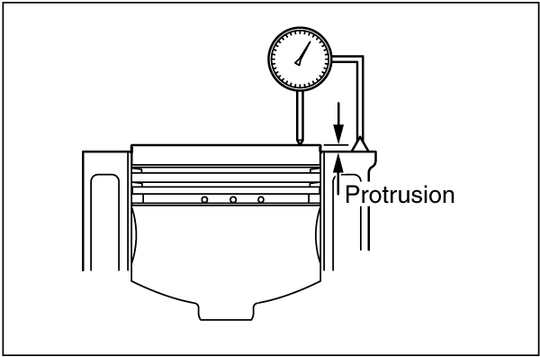

Protrusión del pistón

## 1.2 - ¿Por qué es importante la Protrusión del Pistón?

- Relación de compresión: La relación de compresión es un factor crítico en el rendimiento, la eficiencia y las emisiones de un motor. La protrusión del pistón influye directamente en el volumen de la cámara de combustión, lo que afecta la relación de compresión.
- Eficiencia de combustión: Una protrusión adecuada del pistón asegura que la mezcla aire-combustible se comprima de manera óptima, mejorando la potencia del motor y la eficiencia del combustible.
- Durabilidad del motor: Una protrusión correcta del pistón mantiene la integridad estructural de los componentes del motor, evitando desgastes prematuros.

## 1.3 - ¿Cómo se mide?

La protrusión del pistón se mide con un comparador de carátula. El pistón se lleva al PMS y el comparador se utiliza para medir la distancia que sobresale el pistón por encima de la superficie del bloque del cilindro.

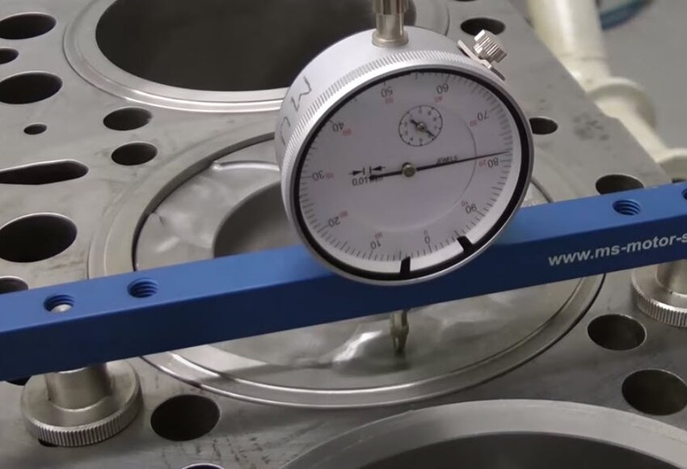

Medición de la protrusión del pistón

## 1.4 - Problemática abordada.

En el proceso de ensamblaje de motores diésel, la medición de la protrusión del pistón se realiza mediante un comparador vinculado a un mecanismo de control automático. Este sistema verifica si la protrusión está dentro de los límites de aceptación. Si es así, el proceso continúa; en caso contrario, el producto es sometido a revisión y reparación.

Durante una auditoría realizada por el departamento de Calidad, se detectó una manipulación en las mediciones de la protrusión del pistón. El personal operativo explicó que algunos modelos de motores presentan valores de protrusión apenas por debajo del límite permitido. En lugar de rechazar estos productos, se ajustaban manualmente las mediciones del comparador para que los valores quedaran dentro de los límites especificados.

Esta práctica, según el personal, tiene raíces culturales e históricas dentro de la organización. Aunque ya había sido reportada a las áreas de soporte pertinentes, la falta de respuesta llevó a adoptar este comportamiento como solución temporal, pese a no ser la más adecuada.

Ante esta situación, el departamento de Calidad propone una investigación exhaustiva para resolver los problemas enfrentados por el personal operativo y garantizar la precisión y la calidad de las mediciones realizadas en el producto final.

# 2 - Limpieza y preparación de los datos.

## 2.1 - Obtención de los datos y delimitación del problema.

En primer lugar, se solicitó al personal operativo que cesara las prácticas indebidas y comenzara a registrar únicamente las mediciones reales. Esto tenía como objetivo garantizar la disponibilidad de datos confiables para el análisis.

En una segunda etapa, se llevó a cabo un relevamiento de los modelos de motores afectados por la problemática. Se identificaron aquellos motores que tienden a presentar mediciones de la protrusión del pistón por debajo de los límites de aceptación establecidos.

El análisis reveló que todos los modelos involucrados pertenecen a una misma familia, caracterizada por compartir componentes clave, como el bloque del motor y el conjunto de compresión. En total, se identificaron cuatro modelos de motores afectados.

Por último, se realizó una consulta a la base de datos de la empresa, extrayendo los valores de todas las mediciones de protrusión registradas desde el año 2020.

## 2.2 - Librerías utilizadas.

```r
library(readxl)
library(ggplot2)
library(dplyr)
library(knitr)
```

## 2.3 - Importar y limpiar los datos.

Se detectaron varias irregularidades en los datos obtenidos de la base de datos:

- Inconsistencias en el formato de los datos: Algunas mediciones utilizan el punto como separador decimal, mientras que otras emplean la coma. Esto genera discrepancias al procesar los datos y requiere estandarización para garantizar la integridad del análisis.
- Mediciones con valor cero: Se identificaron múltiples registros con un valor igual a cero. Estos casos no representan mediciones válidas, ya que corresponden a situaciones en las que el equipo estuvo fuera de servicio o en mantenimiento.
- Valores atípicos extremos: Los datos presentan una cantidad significativa de valores atípicos extremos que deben ser identificados y filtrados antes de proceder con el análisis.

```r
PMS <- read_excel("data/PP.xlsx")

PMS <- PMS |>
  mutate(VALUE = gsub(",", ".", VALUE) |> as.numeric())

PMS <- PMS |>
  mutate(VALUE = if_else(VALUE == 0, NA_real_, VALUE))

Q1 <- quantile(PMS$VALUE, 0.25, na.rm = TRUE)
Q3 <- quantile(PMS$VALUE, 0.75, na.rm = TRUE)
lower_bound <- Q1 - 3.5 * (Q3 - Q1)
upper_bound <- Q3 + 3.5 * (Q3 - Q1)
```

Habitualmente, el rango intercuartílico se multiplica por un factor de 1.5 para identificar valores atípicos. Sin embargo, debido a la naturaleza de los datos analizados, se decidió ampliar este factor a 3.5 con el objetivo de excluir únicamente los valores extremadamente atípicos, preservando aquellos que, aunque se encuentren fuera del rango habitual, podrían ser representativos del comportamiento esperado.

# 3 - Análisis descriptivo.

## 3.1 - Gráfico de dispersión.

Para la primera etapa del análisis, se generó un gráfico de dispersión. En este gráfico, los puntos están diferenciados por colores que representan las dos poblaciones previamente mencionadas. Además, se incluyeron las tolerancias de las especificaciones definidas por el departamento de ingeniería para la protrusión del pistón (0.75 ± 0.12 mm) como referencia visual.

Se dividió a la muestra de datos históricos en dos subpoblaciones. El “Grupo A” corresponde a los datos previos al inicio de la investigación, mientras que el “Grupo B” incluye los datos obtenidos después de que se dejó de manipular el instrumento de medición.

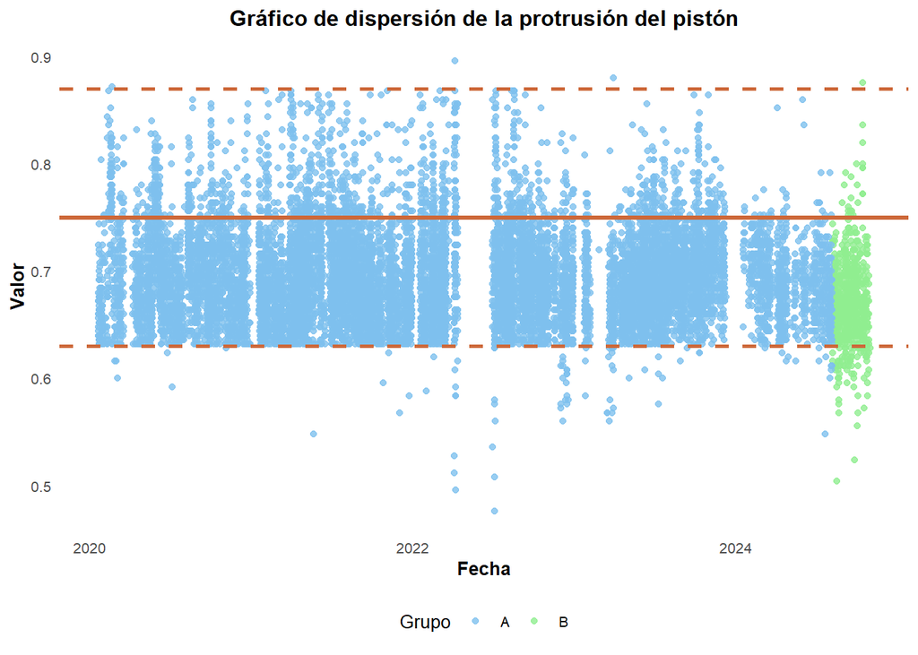

Como se mencionó anteriormente, existen ciertos períodos en los que el equipo estuvo fuera de servicio, lo cual se refleja en los saltos donde no hay mediciones registradas.

También se observa un cambio de tendencia a principios de 2024, con una menor cantidad de puntos que superan el valor nominal para la variable de interés.

Finalmente, parece que, para el grupo B, una mayor proporción de los datos cae fuera de los límites de aceptación.

## 3.2 - Medidas de resumen.

Se calcularon las principales medidas de resumen para poder comparar numéricamente ambos grupos.

```r
Resumen <- PMS |>
  group_by(GRUPO) |>
  summarise(
    media = round(mean(VALUE, na.rm = TRUE), 3),
    mediana = round(median(VALUE, na.rm = TRUE), 3),
    sd = round(sd(VALUE, na.rm = TRUE), 3),
    min = round(min(VALUE, na.rm = TRUE), 3),
    max = round(max(VALUE, na.rm = TRUE), 3),
    n = n()
  )

fallas_por_grupo <- PMS |>
  group_by(GRUPO) |>
  summarise(
    fallas = sum(VALUE < lower_limit | VALUE > upper_limit, na.rm = TRUE),
    total = n(),
    tasa_fallas = round(fallas / total, 3)
  )

Resumen <- left_join(Resumen, fallas_por_grupo, by = "GRUPO")

kable(Resumen, caption = "Resumen de Medidas Descriptivas por Grupo")
```

Resumen de Medidas Descriptivas por Grupo

| GRUPO | media | mediana | sd | min | max | n | fallas | total | tasa_fallas |
| --- | --- | --- | --- | --- | --- | --- | --- | --- | --- |
| A | 0.695 | 0.692 | 0.043 | 0.476 | 0.896 | 14470 | 89 | 14470 | 0.006 |
| B | 0.670 | 0.668 | 0.039 | 0.504 | 0.876 | 699 | 75 | 699 | 0.107 |

# 4 - Conclusiones y acciones a futuro.

## 4.1 - Sobre el proceso.

El análisis realizado ha revelado que el proceso de medición ha estado sujeto a alteraciones a lo largo del tiempo, lo cual ha afectado la confiabilidad de los datos y la precisión de los resultados. Aunque estas manipulaciones se iniciaron como una medida temporal, han generado distorsiones en el análisis de los motores y sus características. Es fundamental poner fin a esta práctica, no solo para asegurar la exactitud de las mediciones, sino también para fomentar una cultura organizacional que valore la precisión y la transparencia. Eliminar estos comportamientos ayudará a fortalecer la confianza en los datos, mejorará la toma de decisiones y contribuirá a un proceso continuo de mejora de la calidad.

## 4.2 - Próximos pasos.

El siguiente paso será convocar a un equipo interdisciplinario de expertos, que incluya tanto a personal especializado en el proceso de producción como a expertos en el producto final. El objetivo será desarrollar un plan de acción que no solo mejore la precisión de las mediciones, sino que también refuerce los procedimientos operativos, asegurando que se mantengan los estándares de calidad y se eviten problemas a futuro.

Este equipo tendrá la tarea de investigar las causas principales de las alteraciones en las mediciones y proponer soluciones prácticas.